# Road Accidents in Leeds City - An Analysis with Linked Data

Raymond Banks, Houda Briwa, Emre Hangül, Hugo Nugra

*Published on 7th of November, 2019*

*The application of this project can be downloaded from [here](https://expo.io/artifacts/b32e6977-9bf0-4e41-bb11-e734ae4121ee)*

# 1 . Introduction

> *The purpose of this study is to to do a practice on how to link a dataset with the other open source data on the world wide web, in other words, how to generate a Linked Data. The dataset to be used contains information about the road accidents in 2017 in Leeds City, UK. The guidelines on the steps for the generation of Linked Data will be explicitly explained with the usage of Google’s Open Refine and its RDF extension.*

# 2 . Guidelines

There are several steps to be followed throughout the analysis of the Leeds City Road Accidents dataset, which can be summarized as follows: *(Radulovic et al. (2014))*

## 2.1 *Selecting the Data Source*

The dataset of the interest comprises of information about the road accidents in Leeds City in the year of 2017. This data set can be found [here](https://www.europeandataportal.eu/data/datasets/road-traffic-accidents?locale=en).

There are numerous factors that effected the decision to select this dataset to be used in this study. First, the data is easily accesible and it is in an easy machine-processable format, namely *csv*. Furthermore, the online page includes a comprehensive description of the dataset, as well as the descriptions for each feature in the data. The license for the dataset is also clearly written and easy to access. Another reason for choosing this dataset is the fact that it would be easily used for the generation of *Linked Data*, as the features of the dataset include information about, for instance, the locations of each accident.

## 2.2 *Obtaining Access to the Data Source*

The Leeds City Road Accidents’ dataset is downloaded from its online [page](https://www.europeandataportal.eu/data/datasets/road-traffic-accidents?locale=en). The dataset is easily obtained since it is an open source data with the license provided by the stakeholders allows downloading of the data from its online page.

## 2.3 *Analyzing License of the Data Source*

The license for the dataset is issued by the *nationalarchives.org* which allows access to dataset freely and flexibly, under the condition of providing a link to the license in wherever it might be used. Thus, the license can be found via this [link.](http://www.nationalarchives.gov.uk/doc/open-government-licence/version/3/)

Looking at the license, one can summarize the license and its conditions as follows:

- The data set is published by the UK Government under the Open Government License for public sector information.
- The license is compatible with the Creative Commons Attribution (CC-BY) license and is maintained by the National Archives.
- The license allows us to use the dataset freely under the proposed application.

## 2.4 *Analyzing the Data source*

A quick look at the Leeds City Road Accidents dataset is as follows:

| Reference.Number | Grid.Ref..Easting | Grid.Ref..Northing | Number.of.Vehicles | Accident.Date | Time..24hr. | X1st.Road.Class...No | Road.Surface | Lighting.Conditions | Weather.Conditions | Type.of.Vehicle | Casualty.Class | Casualty.Severity | Sex.of.Casualty | Age.of.Casualty |
| --- | --- | --- | --- | --- | --- | --- | --- | --- | --- | --- | --- | --- | --- | --- |
| 3AP0313 | 426340 | 428455 | 1 | 3/17/2017 | 815 | A643 | Dry | Daylight: Street lights present | Other | Car | Pedestrian | Serious | Female | 61 |
| 3BE0850 | 430828 | 433222 | 2 | 1/14/2017 | 1330 | A61 | Dry | Daylight: Street lights present | Fine without high winds | Pedal cycle | Driver or rider | Slight | Male | 36 |
| 4110858 | 428940 | 429856 | 2 | 1/1/2017 | 805 | A653 | Wet/Damp | Daylight: Street lights present | Fine without high winds | Car | Driver or rider | Slight | Male | 32 |
| 4110858 | 428940 | 429856 | 2 | 1/1/2017 | 805 | A653 | Wet/Damp | Daylight: Street lights present | Fine without high winds | Car | Driver or rider | Slight | Male | 30 |
| 4111495 | 429899 | 434277 | 2 | 1/1/2017 | 1705 | U | Wet/Damp | Darkness: Street lights present and lit | Raining without high winds | Car | Vehicle or pillion passenger | Slight | Female | 26 |
| 4111706 | 435946 | 436807 | 2 | 1/1/2017 | 1200 | U | Dry | Daylight: Street lights present | Fine without high winds | Car | Driver or rider | Slight | Female | 34 |
| 4120471 | 443658 | 436768 | 3 | 1/2/2017 | 1230 | M1 | Dry | Daylight: Street lights present | Fine without high winds | Car | Driver or rider | Slight | Male | 39 |
| 4120471 | 443658 | 436768 | 3 | 1/2/2017 | 1230 | M1 | Dry | Daylight: Street lights present | Fine without high winds | Car | Driver or rider | Slight | Female | 69 |
| 4121054 | 442103 | 434572 | 2 | 1/2/2017 | 1807 | M1 | Dry | Darkness: No street lighting | Fine without high winds | Car | Driver or rider | Slight | Male | 18 |
| 4121054 | 442103 | 434572 | 2 | 1/2/2017 | 1807 | M1 | Dry | Darkness: No street lighting | Fine without high winds | Car | Vehicle or pillion passenger | Serious | Female | 17 |

[output cut: 2193 more lines]

The road accident dataset consists of 2203 observations of accidents that happened in Leeds City in 2017, with each observation having 15 different features that are explained below:

*Features(variables) that hold integer values*:

- **Grid Ref(erence) : Easting** — Denotes geographical location of an accident, horizontally.
- **Grid Ref(erence): Northing** — Denotes geographical location of an accident, vertically.
- **Number of Vehicles** — Denotes number of vehicles involved in an accident (ranges from 1 to 7).
- **Time (24 Hour Format)** — Time (hours, minutes) of an accident in a day with 24-hour format .
- **Age of Casualty** — Age of the person that had a casualty due to an accident (ranges from 1 to 96).

After some thought process, it is determined that some of the features should be transformed to better fit the aims of the study. For instance, the *Grid Ref:Easting* and *Grid Ref:Northing* features are transformed into *Latitude* and *Longitude* which have much wider usage in terms of determining the locations of an observation. Other changes include formatting the *Time* column, simplifying the values of *Type of Vehicle* column and creating a new column named *StreetName* which holds the string values as the addresses of the accident that correspond to the *latitude* and *longitude* values. This extraction of new information about street names is possible due to a feature called *reconciliation*. More information on this feature will be given in chapter 2.7.

Here is a quick look at the dataset after these transformation are done:

| Reference.Number | Easting | Northing | Longitude | Latitude | PostalCode | City | StreetName | Number.of.Vehicles | DateTime | Road.Number | Road.Surface.Condition | Lighting.Conditions | Weather.Conditions | Type.of.Vehicle | Casualty.Class | Casualty.Severity | Sex.of.Casualty | Age.of.Casualty |
| --- | --- | --- | --- | --- | --- | --- | --- | --- | --- | --- | --- | --- | --- | --- | --- | --- | --- | --- |
| 3AP0313 | 426340 | 428455 | -1.602029 | 53.751802 | LS27 9PP | Leeds | Springfield Road | 1 | 2017-01-17T08:15:00Z | A643 | Dry | Daylight: Street lights present | Other | car | Pedestrian | Serious | female | 61 |
| 3BE0850 | 430828 | 433222 | -1.533496 | 53.794401 | LS9 8DZ | Leeds | East Street | 2 | 2017-01-14T13:30:00Z | A61 | Dry | Daylight: Street lights present | Fine without high winds | bicycle | Driver or rider | Slight | male | 36 |
| 4110858 | 428940 | 429856 | -1.56247 | 53.764256 | LS11 5LG | Leeds | Dewsbury Road | 2 | 2017-01-01T08:05:00Z | A653 | Wet/Damp | Daylight: Street lights present | Fine without high winds | car | Driver or rider | Slight | male | 32 |
| 4110858 | 428940 | 429856 | -1.56247 | 53.764256 | LS11 5LG | Leeds | Dewsbury Road | 2 | 2017-01-01T08:05:00Z | A653 | Wet/Damp | Daylight: Street lights present | Fine without high winds | car | Driver or rider | Slight | male | 30 |
| 4111495 | 429899 | 434277 | -1.547496 | 53.803937 | LS2 9EN | Leeds | Woodhouse Lane | 2 | 2017-01-01T17:05:00Z | U | Wet/Damp | Darkness: Street lights present and lit | Raining without high winds | car | Vehicle or pillion passenger | Slight | female | 26 |
| 4111706 | 435946 | 436807 | -1.455388 | 53.826294 |  | Leeds | Hebden Approach | 2 | 2017-01-01T00:00:00Z | U | Dry | Daylight: Street lights present | Fine without high winds | car | Driver or rider | Slight | female | 34 |
| 4120471 | 443658 | 436768 | -1.33824 | 53.825355 | LS25 | Leeds | Lotherton Lane | 3 | 2017-01-02T00:30:00Z | M1 | Dry | Daylight: Street lights present | Fine without high winds | car | Driver or rider | Slight | male | 39 |
| 4120471 | 443658 | 436768 | -1.33824 | 53.825355 | LS25 | Leeds | Lotherton Lane | 3 | 2017-01-02T00:30:00Z | M1 | Dry | Daylight: Street lights present | Fine without high winds | car | Driver or rider | Slight | female | 69 |
| 4121054 | 442103 | 434572 | -1.362161 | 53.805746 | LS25 | Leeds |  | 2 | 2017-01-02T18:07:00Z | M1 | Dry | Darkness: No street lighting | Fine without high winds | car | Driver or rider | Slight | male | 18 |
| 4121054 | 442103 | 434572 | -1.362161 | 53.805746 | LS25 | Leeds |  | 2 | 2017-01-02T18:07:00Z | M1 | Dry | Darkness: No street lighting | Fine without high winds | car | Vehicle or pillion passenger | Serious | female | 17 |

[output cut: 2193 more lines]

Furthermore, using the now available *StreetName*, *latitude* and *longitude* values, the accidents can be visualized through a map. Below is an interactive map that shows the exact addresses of each accident by using different colors of circles for different severities for casualties. The street names can be seen by clicking of any of the circles. Note that most of the casualties are classified as *slight* and very few of them are classified as *fatal*.

[interactive chart not shown]

## 2.5 *Defining Resource Naming Strategy*

For the purpose of the generation of Linked Data, there are 4 principles defined (Berners-Lee (2009)) as follows:

- Use URIs as names for things.
- Use HTTP URIs so that people can look up those names.
- When someone looks up a URI, provide useful information using the standards (RDF, SPARQL).
- Include links to other URIs so that they can discover more things.

Furthermore, there are 2 general forms of URI: A *Hash URI (#)* and a *Slash URI(/)*. Several different principles are defined worldwide to choose which URI style should be used (Love (2014)) in which situation. Following one of the common patterns, the resource naming strategy used in this study is as follows:

- The URI domain to be used is **http://group03.org/ .** This domain is chosen because it’s available.
- Ontology model classes: the classes in the ontology will have the form **http://www.group03.org/saferoads/TrafficAccidentsontology#ClassNAME**.
- Ontology model properties: the properties in the ontology will have the form **http://www.group03.org/saferoads/TrafficAccidentsontology#PropertyNAME**.
- Instances: the instances in the ontology will have the form **http://www.group03.org/saferoads/TrafficAccidentsontology/resource/ClassNAME#IDENTIFIER**.

## 2.6 *Developing Ontology*

To construct the ontology for this road accident dataset, the first thing to do is to decide on what the *classes*, *properties* and *instances* of the ontology would be according to the road accident dataset. After some thought processes, these features are defined as the following:

- All of the 15 features of the dataset are divided into classes as:
  - 11 classes without any *subclasses*:
    - *Accident*
    - *city*
    - *Environment*
    - *Latitude*
    - *Lighting-Conditions*
    - *Longitude*
    - *Postal_code*
    - *Road_profile*
    - *Street*
    - *surface-condition*
    - *Weather_condition*
  - 4 classes with *subclasses* of the classes *Casualty* and *Vehicle*:
    - *class(casualty)*
    - *severity(casualty)*
    - *sex(casualty)*
    - *type(vehicle)*
- 7 properties with no sub-properties: (with their *domains* and *ranges* are in the parantheses as (domain:range)):
  - *has_city*(Accident:city)
  - *has_datetime* (Accident:time,Accident:date)
  - *has_latitude* (Accident:Latitude)
  - *has_longitude* (Accident: Longitude)
  - *has_postal_code* (Accident: Postal_code)
  - *has_street* (Accident: Street)
  - *has_type_of_vehicle* (Accident:type)
- 2 properties *has_casualty* (Accident:Casualty) , *has_environment* (Accident:environment) with 7 sub-properties:
  - *has_age* (Casualty:age)
  - *has_class* (Casualt:class)
  - *has_gender* (Casualty:sex)
  - *has_level_of_severity* (Casualty:severity)
  - *has_lightning_condition* (environment:lightning_conditions)
  - *has_surface_condition* (environment:surface_condition)
  - *has_weather_condition* (environment:Weather_condition)
- 25 instances of the classes, namely: (individual:class)
  - Car, Motorcycle, Pedal_cycleCar, Taxi/Private_hireCar : *Type*
  - Fine_with_high_winds, fine_without_high_winds, raining_with_high_winds, raining_without_high_winds, snowing_with_high_winds, snowing_without_high_winds : *weather_condition*
  - Dry, Frost/Ice, Snow, Wet/Damp : *surface_condition*
  - Darkness:_no_street_lightning, Darkness:_Street_lights_present_and_lit, Daylight:Street_lights_present : *Lighting_Conditions*
  - Driver_or_rider, Pedestrian, Vehicle_or_pillion_passenger : *casualty_class*
  - Fatal, serious, slight : *casualty_Severity*
  - Female, male : *casualty_sex*

The second part for the development of the road accident ontology is searching for possible existing ontologies that could suit best for the values of the dataset. This process is mostly done via the online site *Linked Open Vocabularies (LOV)* which can be found [here](https://lov.linkeddata.es/dataset/lov/).

The ontology for the road accidents are created by using an ontology creation tool, *Protege*. Furthermore, the resulting ontology is visualized by the “VOWL Viewer” tool of the Protege. A screenshot of the ontology is given below.

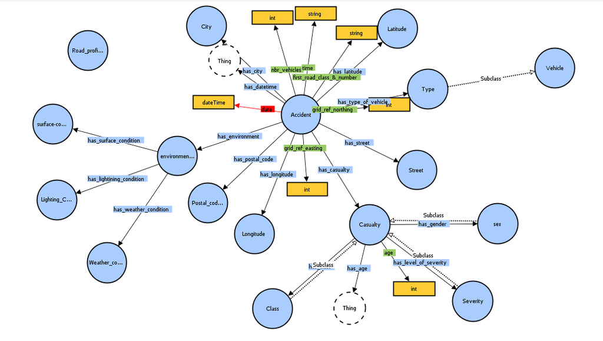

Road Accident Ontology